# Airbnb di Firenze

by Emanuele Driussi

# Quali domande mi sono posto?

- Qual è la distribuzione dei prezzi delle camere nei vari quartieri e per tipologie di camera?
- Quali sono le differenze di prezzo nelle principali città italiane in base alle mie esigenze?

# Il dataset utilizzato

## Riferimento online

Sito web: [Inside Airbnb](https://insideairbnb.com/get-the-data/)

## Ultimo aggiornamento

- Firenze, Milano e Napoli: 22 giugno 2024
- Roma: 15 giugno 2024
- Venezia: 7 giugno 2024

## Contenuto

Il sito per ogni città ha diversi tipi di dataset, per il mio progettto ho usato i dataset inerenti agli annunci.

Non ci sono dati inerenti alle recensioni e al calendario.

Per Firenze ho utilizzato anche un file geojson contenente i bordi dei quartieri. Il prezzo degli airbnb è in dollaro americano.

# Filtraggio sul dataset

Il progetto è focalizzato su Airbnb che costano meno di 1000$ per:

- Evitare errori di prezzo sia del dataset sia dell'annuncio
- Focalizzarsi su airbnb che hanno il solo scopo di dormire

# Distribuzione dei prezzi in base al quartiere

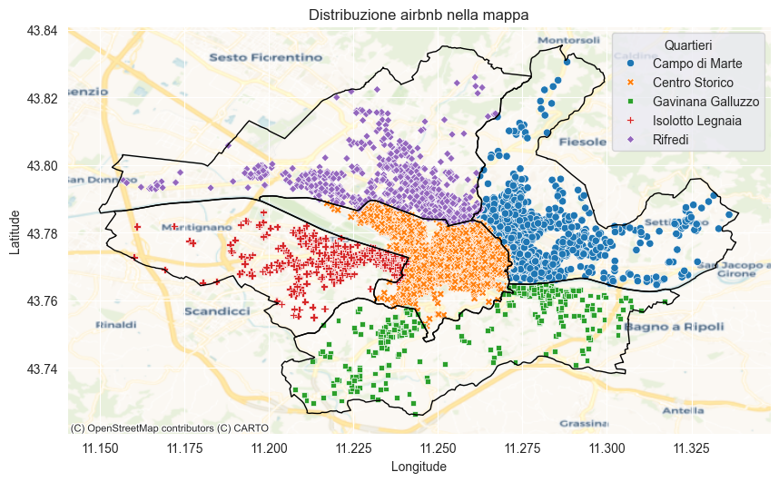

```
Il numero totale di aibnb è di  10743
```

[figure not shown]

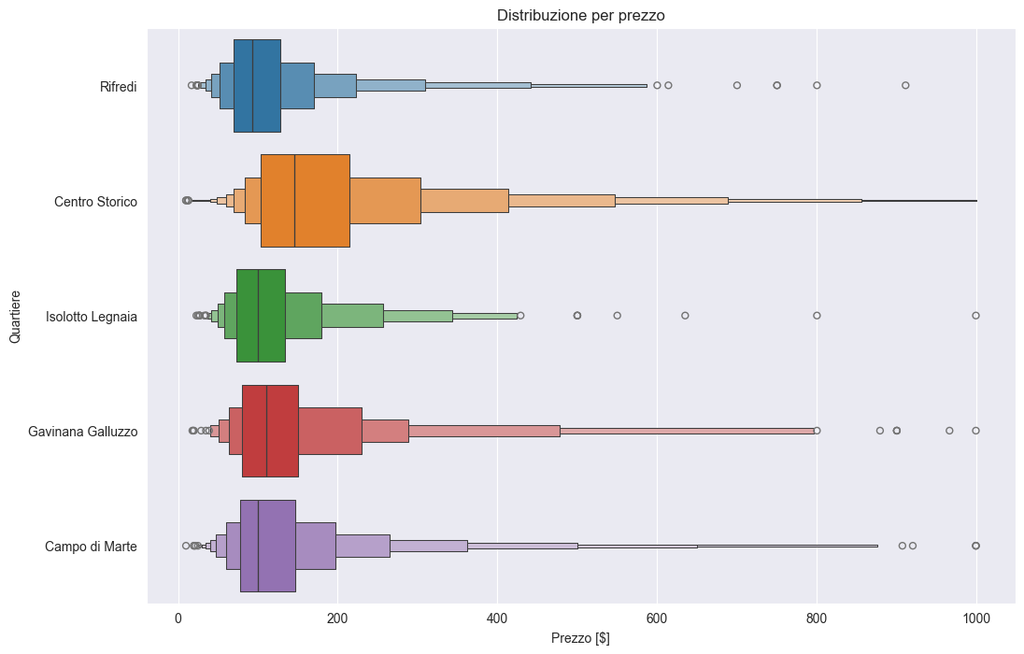

[interactive chart not shown]

# Distribuzione dei prezzi in base al tipo di camera

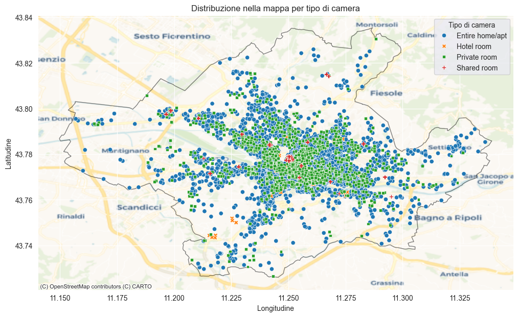

[figure not shown]

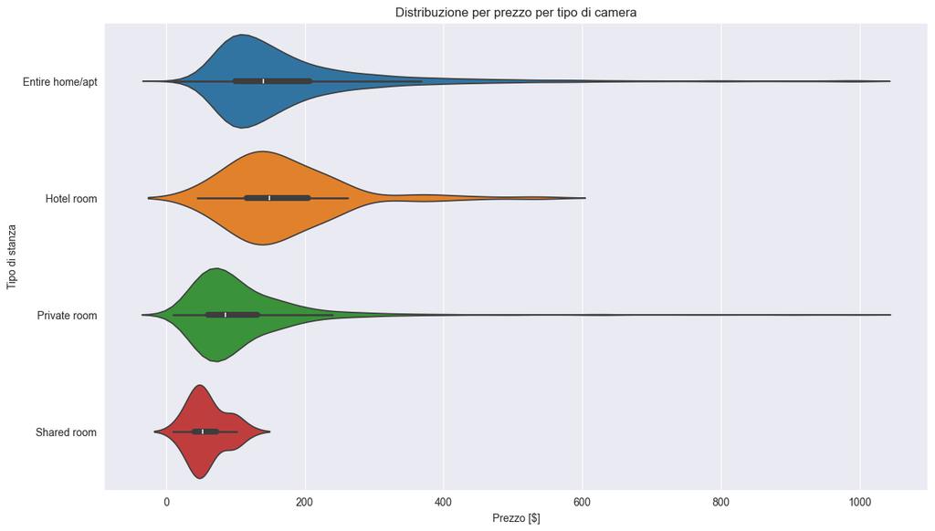

[interactive chart not shown]

# Per rispondere alla seconda domanda

## Che Airbnb cercavo:

- Airbnb per due ospiti
- Airbnb per due notti
- Airbnb in zona centrale della città
- Airbnb con camera privata
- Airbnb con aria condizionata

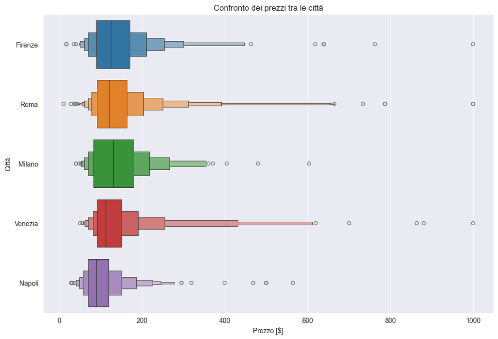

# Conclusioni

### Distribuzione dei prezzi in base alla tipologia di camera e al quartiere

| Tipo di Camera | Mediana Prezzo [$] |
| --- | --- |
| Hotel room | 149.0 |
| Entire home/apt | 140.0 |
| Private room | 86.0 |
| Shared room | 53.0 |

[output not shown]

### Classifica delle città più costose

| Città | Prezzo medio [$] |
| --- | --- |
| Milano | 130.00 |
| Firenze | 125.00 |
| Roma | 120.00 |
| Venezia | 112.00 |
| Napoli | 89.00 |